# Practical Machine Learning Course: Prediction Assignment Writeup

# Overview

This is the final report of the Peer Assessment project from Coursera’s course Practical Machine Learning. It has been created employing RStudio, using its knitr functions.

The main goal of the project is to predict the manner in which 6 participants performed some exercise as described below. This is the “classe” variable in the training set. Using the training data, several machine learning algorithms have been tested to identify the best performer in terms of accuracy of the predictions. The best performer is applied to the 20 test cases available in the test data and the predictions are submitted in appropriate format to the Course Project Prediction Quiz for automated grading.

# Background

Using devices such as Jawbone Up, Nike FuelBand, and Fitbit it is now possible to collect a large amount of data about personal activity relatively inexpensively. These type of devices are part of the quantified self movement – a group of enthusiasts who take measurements about themselves regularly to improve their health, to find patterns in their behavior, or because they are tech geeks. One thing that people regularly do is quantify how much of a particular activity they do, but they rarely quantify how well they do it. In this project, your goal will be to use data from accelerometers on the belt, forearm, arm, and dumbell of 6 participants. They were asked to perform barbell lifts correctly and incorrectly in 5 different ways. More information is available from the website here: http://web.archive.org/web/20161224072740/http:/groupware.les.inf.puc-rio.br/har (see the section on the Weight Lifting Exercise Dataset).

The training data for this project are available here:

https://d396qusza40orc.cloudfront.net/predmachlearn/pml-training.csv

The test data are available here:

https://d396qusza40orc.cloudfront.net/predmachlearn/pml-testing.csv

The data for this project come from http://groupware.les.inf.puc-rio.br/har. Full source:

Velloso, E.; Bulling, A.; Gellersen, H.; Ugulino, W.; Fuks, H. “Qualitative Activity Recognition of Weight Lifting Exercises. Proceedings of 4th International Conference in Cooperation with SIGCHI (Augmented Human ’13)”. Stuttgart, Germany: ACM SIGCHI, 2013.

My special thanks to the above mentioned authors for being so generous in allowing their data to be used for this kind of assignment.

# Data loading and cleaning

Loading libraries:

```r
library(knitr)
library(caret)
```

```r
library(rpart)
library(rpart.plot)
library(rattle)
library(randomForest)
library(corrplot)
```

**a. Loading the data**

The following lines permit to download the files containing the training and the testing sets:

```r
train0 <- read.csv(url("https://d396qusza40orc.cloudfront.net/predmachlearn/pml-training.csv"),header=TRUE)
test0 <- read.csv(url("https://d396qusza40orc.cloudfront.net/predmachlearn/pml-testing.csv"),header=TRUE)
```

I will now make a preliminary analysis of both the train and test set to understand if there are missing entries or features that need a special treatment.

For the training set this is the outcome:

```r
dim(train0)
```

```
## [1] 19622   160
```

```r
str(train0)
```

```
## 'data.frame':    19622 obs. of  160 variables:
##  $ X                       : int  1 2 3 4 5 6 7 8 9 10 ...
##  $ user_name               : Factor w/ 6 levels "adelmo","carlitos",..: 2 2 2 2 2 2 2 2 2 2 ...
##  $ raw_timestamp_part_1    : int  1323084231 1323084231 1323084231 1323084232 1323084232 1323084232 1323084232 1323084232 1323084232 1323084232 ...
##  $ raw_timestamp_part_2    : int  788290 808298 820366 120339 196328 304277 368296 440390 484323 484434 ...
##  $ cvtd_timestamp          : Factor w/ 20 levels "02/12/2011 13:32",..: 9 9 9 9 9 9 9 9 9 9 ...
##  $ new_window              : Factor w/ 2 levels "no","yes": 1 1 1 1 1 1 1 1 1 1 ...
##  $ num_window              : int  11 11 11 12 12 12 12 12 12 12 ...
##  $ roll_belt               : num  1.41 1.41 1.42 1.48 1.48 1.45 1.42 1.42 1.43 1.45 ...
##  $ pitch_belt              : num  8.07 8.07 8.07 8.05 8.07 8.06 8.09 8.13 8.16 8.17 ...
##  $ yaw_belt                : num  -94.4 -94.4 -94.4 -94.4 -94.4 -94.4 -94.4 -94.4 -94.4 -94.4 ...
##  $ total_accel_belt        : int  3 3 3 3 3 3 3 3 3 3 ...
##  $ kurtosis_roll_belt      : Factor w/ 397 levels "","-0.016850",..: 1 1 1 1 1 1 1 1 1 1 ...
##  $ kurtosis_picth_belt     : Factor w/ 317 levels "","-0.021887",..: 1 1 1 1 1 1 1 1 1 1 ...
##  $ kurtosis_yaw_belt       : Factor w/ 2 levels "","#DIV/0!": 1 1 1 1 1 1 1 1 1 1 ...
```

[output cut: 86 more lines]

```r
#summary(train0)
```

For the testing set this is the outcome:

```r
dim(test0)
```

```
## [1]  20 160
```

```r
str(test0)
```

```
## 'data.frame':    20 obs. of  160 variables:
##  $ X                       : int  1 2 3 4 5 6 7 8 9 10 ...
##  $ user_name               : Factor w/ 6 levels "adelmo","carlitos",..: 6 5 5 1 4 5 5 5 2 3 ...
##  $ raw_timestamp_part_1    : int  1323095002 1322673067 1322673075 1322832789 1322489635 1322673149 1322673128 1322673076 1323084240 1322837822 ...
##  $ raw_timestamp_part_2    : int  868349 778725 342967 560311 814776 510661 766645 54671 916313 384285 ...
##  $ cvtd_timestamp          : Factor w/ 11 levels "02/12/2011 13:33",..: 5 10 10 1 6 11 11 10 3 2 ...
##  $ new_window              : Factor w/ 1 level "no": 1 1 1 1 1 1 1 1 1 1 ...
##  $ num_window              : int  74 431 439 194 235 504 485 440 323 664 ...
##  $ roll_belt               : num  123 1.02 0.87 125 1.35 -5.92 1.2 0.43 0.93 114 ...
##  $ pitch_belt              : num  27 4.87 1.82 -41.6 3.33 1.59 4.44 4.15 6.72 22.4 ...
##  $ yaw_belt                : num  -4.75 -88.9 -88.5 162 -88.6 -87.7 -87.3 -88.5 -93.7 -13.1 ...
##  $ total_accel_belt        : int  20 4 5 17 3 4 4 4 4 18 ...
##  $ kurtosis_roll_belt      : logi  NA NA NA NA NA NA ...
##  $ kurtosis_picth_belt     : logi  NA NA NA NA NA NA ...
##  $ kurtosis_yaw_belt       : logi  NA NA NA NA NA NA ...
```

[output cut: 86 more lines]

```r
#summary(test0)
```

**b. Cleaning the data**

The preliminary analysis shows there are a lot of features having NA or blanked entries in both the training and testing sets. Due to this, I will now proceed to remove the features having NA and/or missing values. Despite this is the dirtiest strategy, it is, on the other hand, the simplest.

I start with the training set:

```r
idCol <- which(colSums(is.na(train0) |train0=="") > 0.95*dim(train0)[1])
train1 <- train0[,-idCol]
train1 <- train1[,-c(1:7)]
dim(train1)
```

```
## [1] 19622    53
```

Now, I will proceed to do the same with the test set, making sure we are eliminating exactly the same columns:

```r
test1 <- test0[,-idCol]
test1 <- test1[,-c(1:7)]
dim(test1)
```

```
## [1] 20 53
```

The final sets, that will be used for the machine learning runs, have both 53 features.

# Building and Assessing the models

Five methods will be applied to model the regressions (in the Train dataset) and the best one (with higher accuracy when applied to the Test dataset) will be used for the quiz predictions.

The methods are: Random Forests (RF), Decision Tree (DT), Generalized Boosted Model (GBM), Linear Discriminant Analysis (LDA) and Support Vector Machines (SVM).

It will be used a 5 fold cross validation on the training set to indentify the algorithm with the higher performance in terms of accuracy.

**a. Random Forest (RF)**

Here, I will be testing the algorithm Random Forest.

```r
set.seed(12345)
cv <- trainControl(method="cv", number=5, verboseIter=FALSE)
rf <- train(classe ~ ., data=train1, method="rf",
                          trControl=cv)
print(rf)
```

```
## Random Forest
##
## 19622 samples
##    52 predictor
##     5 classes: 'A', 'B', 'C', 'D', 'E'
##
## No pre-processing
## Resampling: Cross-Validated (5 fold)
## Summary of sample sizes: 15699, 15697, 15698, 15699, 15695
## Resampling results across tuning parameters:
##
##   mtry  Accuracy   Kappa
##    2    0.9943939  0.9929084
##   27    0.9941902  0.9926505
##   52    0.9890945  0.9862036
##
## Accuracy was used to select the optimal model using the largest value.
## The final value used for the model was mtry = 2.
```

```r
rf$finalModel
```

```
##
## Call:
##  randomForest(x = x, y = y, mtry = param$mtry)
##                Type of random forest: classification
##                      Number of trees: 500
## No. of variables tried at each split: 2
##
##         OOB estimate of  error rate: 0.41%
## Confusion matrix:
##      A    B    C    D    E  class.error
## A 5579    1    0    0    0 0.0001792115
## B   12 3778    7    0    0 0.0050039505
## C    0   14 3407    1    0 0.0043834015
## D    0    0   37 3176    3 0.0124378109
## E    0    0    0    5 3602 0.0013861935
```

The accuracy obtained by RF is 0.994.

**b. Decision Trees (DT)**

Here, I will be testing the algorithm Decision Trees.

```r
set.seed(12345)
cv <- trainControl(method="cv", number=5, verboseIter=FALSE)
dt <- train(classe ~ ., data=train1, method="rpart",
                          trControl=cv)
print(dt)
```

```
## CART
##
## 19622 samples
##    52 predictor
##     5 classes: 'A', 'B', 'C', 'D', 'E'
##
## No pre-processing
## Resampling: Cross-Validated (5 fold)
## Summary of sample sizes: 15699, 15697, 15698, 15699, 15695
## Resampling results across tuning parameters:
##
##   cp          Accuracy   Kappa
##   0.03567868  0.5041256  0.35243260
##   0.05998671  0.4421644  0.25193227
##   0.11515454  0.3489941  0.09841228
##
## Accuracy was used to select the optimal model using the largest value.
## The final value used for the model was cp = 0.03567868.
```

```r
dt$finalModel
```

```
## n= 19622
##
## node), split, n, loss, yval, (yprob)
##       * denotes terminal node
##
##  1) root 19622 14042 A (0.28 0.19 0.17 0.16 0.18)
##    2) roll_belt< 130.5 17977 12411 A (0.31 0.21 0.19 0.18 0.11)
##      4) pitch_forearm< -33.95 1578    10 A (0.99 0.0063 0 0 0) *
##      5) pitch_forearm>=-33.95 16399 12401 A (0.24 0.23 0.21 0.2 0.12)
##       10) magnet_dumbbell_y< 439.5 13870  9953 A (0.28 0.18 0.24 0.19 0.11)
##         20) roll_forearm< 123.5 8643  5131 A (0.41 0.18 0.18 0.17 0.061) *
##         21) roll_forearm>=123.5 5227  3500 C (0.077 0.18 0.33 0.23 0.18) *
##       11) magnet_dumbbell_y>=439.5 2529  1243 B (0.032 0.51 0.043 0.22 0.19) *
##    3) roll_belt>=130.5 1645    14 E (0.0085 0 0 0 0.99) *
```

Plotting the tree obtained by the algorithm

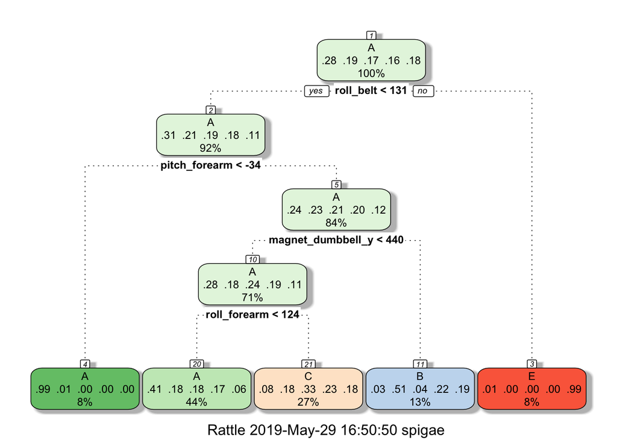

```r
#print(dt)
fancyRpartPlot(dt$finalModel)
```

The accuracy obtained by DT is 0.504.

**c. Generalized Boosted Model (GBM)**

Here, I will be testing the algorithm Generalized Boosted Model.

```r
set.seed(12345)
cv <- trainControl(method="cv", number=5, verboseIter=FALSE)
gbm <- train(classe ~ ., data=train1, method="gbm",
                          trControl=cv, verbose=FALSE)
print(gbm)
```

```
## Stochastic Gradient Boosting
##
## 19622 samples
##    52 predictor
##     5 classes: 'A', 'B', 'C', 'D', 'E'
##
## No pre-processing
## Resampling: Cross-Validated (5 fold)
## Summary of sample sizes: 15699, 15697, 15698, 15699, 15695
## Resampling results across tuning parameters:
##
##   interaction.depth  n.trees  Accuracy   Kappa
##   1                   50      0.7527251  0.6864087
##   1                  100      0.8195897  0.7716488
##   1                  150      0.8544488  0.8158014
##   2                   50      0.8543981  0.8155468
##   2                  100      0.9075009  0.8829428
##   2                  150      0.9338485  0.9162962
##   3                   50      0.8975125  0.8702344
##   3                  100      0.9420032  0.9266066
##   3                  150      0.9624396  0.9524769
##
## Tuning parameter 'shrinkage' was held constant at a value of 0.1
##
## Tuning parameter 'n.minobsinnode' was held constant at a value of 10
## Accuracy was used to select the optimal model using the largest value.
## The final values used for the model were n.trees = 150,
##  interaction.depth = 3, shrinkage = 0.1 and n.minobsinnode = 10.
```

```r
gbm$finalModel
```

```
## A gradient boosted model with multinomial loss function.
## 150 iterations were performed.
## There were 52 predictors of which 52 had non-zero influence.
```

Plotting the accuracy as a function of the boosting interaction and the maximum tree dept:

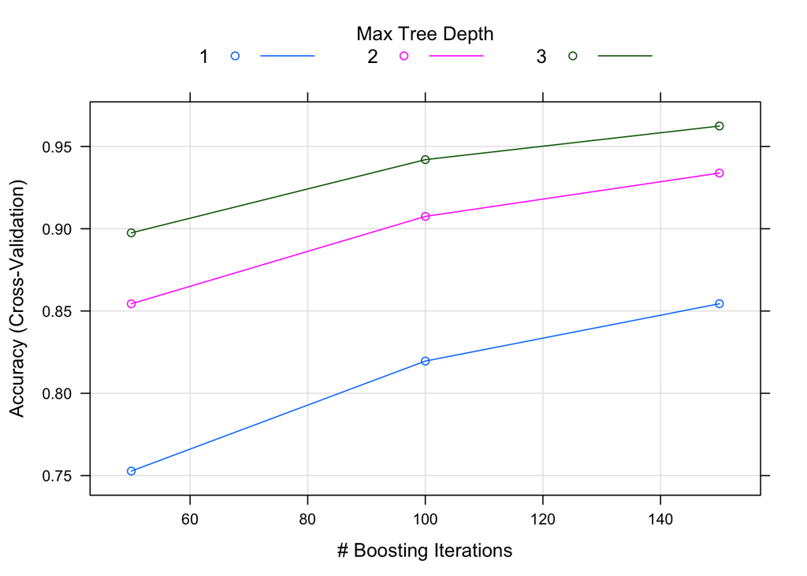

```r
plot(gbm)
```

The accuracy obtained by GBM is 0.962.

**d. Linear Discriminant Analysis (LDA)**

Here, I will be testing the algorithm Linear Discriminant Analysis.

```r
set.seed(12345)
cv <- trainControl(method="cv", number=5, verboseIter=FALSE)
lda <- train(classe ~ ., data=train1, method="lda", trControl=cv)
print(lda)
```

```
## Linear Discriminant Analysis
##
## 19622 samples
##    52 predictor
##     5 classes: 'A', 'B', 'C', 'D', 'E'
##
## No pre-processing
## Resampling: Cross-Validated (5 fold)
## Summary of sample sizes: 15699, 15697, 15698, 15699, 15695
## Resampling results:
##
##   Accuracy  Kappa
##   0.703089  0.6243041
```

```r
lda$finalModel
```

```
## Call:
## lda(x, grouping = y)
##
## Prior probabilities of groups:
##         A         B         C         D         E
## 0.2843747 0.1935073 0.1743961 0.1638977 0.1838243
##
## Group means:
##   roll_belt  pitch_belt   yaw_belt total_accel_belt gyros_belt_x
## A  59.34989  0.35583871 -12.033455         10.67814 -0.004922939
## B  65.16313 -0.01914669 -13.291030         11.13853 -0.004824862
## C  64.81424 -1.04698714  -7.379407         11.18381 -0.014921099
## D  60.85452  1.81800684 -17.864089         11.22917 -0.014732587
## E  74.21647  0.50276130  -5.419947         12.67397  0.009564735
##   gyros_belt_y gyros_belt_z accel_belt_x accel_belt_y accel_belt_z
## A   0.04048566   -0.1213746    -6.261290     28.94265    -62.68387
## B   0.04253095   -0.1347748    -4.934422     31.97603    -73.60047
## C   0.03949445   -0.1350994    -4.048802     31.11748    -71.07949
## D   0.03633396   -0.1365641    -8.279851     30.46300    -69.24192
## E   0.03808983   -0.1305517    -4.331023     28.92515    -91.28888
##   magnet_belt_x magnet_belt_y magnet_belt_z   roll_arm  pitch_arm
## A      57.82975      602.1978     -337.9289 -0.5660538   3.383511
## B      49.21991      599.3790     -336.6987 32.0088491  -6.560208
## C      57.21186      599.9357     -337.3501 24.9816949  -1.635038
## D      48.67413      594.2848     -340.6213 22.6384359 -10.460211
## E      63.51733      568.0133     -378.4549 20.2917300 -12.539767
##      yaw_arm total_accel_arm gyros_arm_x gyros_arm_y gyros_arm_z
## A -11.755769        27.37849  0.02743548  -0.2210914   0.2643136
## B   7.903139        26.53095  0.02274954  -0.2859679   0.2659310
## C   3.935570        24.30216  0.10156341  -0.2638574   0.2744711
## D   5.151536        23.39521  0.03544776  -0.2527550   0.2652208
## E  -1.826180        24.56834  0.03833102  -0.2797754   0.2802717
##   accel_arm_x accel_arm_y accel_arm_z magnet_arm_x magnet_arm_y
## A  -132.15789    47.17778   -75.36254    -19.14964    235.60789
## B   -42.32763    25.42218   -95.62813    234.74032    130.17408
## C   -78.04880    41.00701   -53.60959    155.86937    190.20134
## D    15.78638    25.01710   -47.83986    397.18252     97.03545
## E   -18.73025    16.37344   -76.80704    323.48489     83.48461
##   magnet_arm_z roll_dumbbell pitch_dumbbell yaw_dumbbell
## A     410.6249      21.58705     -18.917893     1.496744
```

[output cut: 137 more lines]

```
## yaw_forearm           1.144113e-03
## total_accel_forearm   2.577901e-03
## gyros_forearm_x       1.373483e-01
## gyros_forearm_y       5.898712e-03
## gyros_forearm_z      -3.601500e-02
## accel_forearm_x       3.871118e-03
## accel_forearm_y      -2.012050e-03
## accel_forearm_z      -4.542622e-03
## magnet_forearm_x     -1.166947e-03
## magnet_forearm_y      3.283250e-04
## magnet_forearm_z      1.129935e-03
##
## Proportion of trace:
##    LD1    LD2    LD3    LD4
## 0.4903 0.2411 0.1546 0.1140
```

The accuracy obtained by LDA is 0.703.

**d. Support Vector Machines (SVM)**

Here, I will be testing the algorithm Support Vector Machines.

```r
set.seed(12345)
cv <- trainControl(method="cv", number=5, verboseIter=FALSE)
svm <- train(classe ~ ., data=train1, method = "svmLinear",
                    preProc = c("center","scale"), trControl=cv)
print(svm)
```

```
## Support Vector Machines with Linear Kernel
##
## 19622 samples
##    52 predictor
##     5 classes: 'A', 'B', 'C', 'D', 'E'
##
## Pre-processing: centered (52), scaled (52)
## Resampling: Cross-Validated (5 fold)
## Summary of sample sizes: 15699, 15697, 15698, 15699, 15695
## Resampling results:
##
##   Accuracy   Kappa
##   0.7865666  0.7286667
##
## Tuning parameter 'C' was held constant at a value of 1
```

```r
svm$finalModel
```

```
## Support Vector Machine object of class "ksvm"
##
## SV type: C-svc  (classification)
##  parameter : cost C = 1
##
## Linear (vanilla) kernel function.
##
## Number of Support Vectors : 10037
##
## Objective Function Value : -2007.688 -1713.551 -1472.965 -902.2759 -1878.402 -1218.151 -2456.133 -1679.815 -1474.953 -1689.109
## Training error : 0.207216
```

The accuracy obtained by SVM is 0.786.

# Predictions

The accuracies of the 5 employed algorithms are:

1. Random Forest: 0.994
2. Decision Tree: 0.504
3. Generalized Boosted Model: 0.962
4. Linear Discriminant Analysis: 0.703
5. Support Vector Machines: 0.786

Being the algorithm Random Forest producing the most accurate model, I will apply it to predict the 20 quiz results from the test dataset.

```r
predictionsRF <- predict(rf, newdata=test1)
predictionsRF
```

```
##  [1] B A B A A E D B A A B C B A E E A B B B
## Levels: A B C D E
```